# Linear Regression

```python
#데이터 행렬 연산 패키지
import numpy as np
#데이터 구성 패키지
import pandas as pd
#시각화 패키지
import seaborn as sns
import matplotlib
#데이터 시각화 패키지
import matplotlib.pyplot as plt
#통계분석 패키지
import scipy.stats as stats
#선형 모델 패키지
import statsmodels.api as sm
#회귀분석 패키지
from statsmodels.formula.api import ols
#평가함수 패키지
from statsmodels.tools.eval_measures import rmse
#주피터사용시 그래프 자동 출력 옵션
#다중공선성 패키지 불러오기
from statsmodels.stats.outliers_influence import variance_inflation_factor
#sklearn 선형회귀 모형 -> 변수 선택법을 위함
from sklearn.linear_model import LinearRegression
#변수 선택법(후진제거법)
from sklearn.feature_selection import RFE
#데이터 scale
from sklearn.preprocessing import scale
%matplotlib inline
matplotlib.rc('font',family="NanumbarunGothic")
plt.rcParams['axes.unicode_minus'] = False

#pandas describe 생략되는 것 표시
pd.set_option('display.max_columns', None)
pd.set_option('display.expand_frame_repr', False)
pd.set_option('max_colwidth', -1)
```

## Data Loading & EDA

```python
body = pd.read_csv("/home/pirl/Downloads/체질검사.csv", engine = "python")
body.info()
body.isnull().sum()
```

```
<class 'pandas.core.frame.DataFrame'>
RangeIndex: 252 entries, 0 to 251
Data columns (total 14 columns):
FAT        252 non-null float64
AGE        252 non-null int64
WEIGHT     252 non-null float64
HEIGHT     252 non-null float64
NECK       252 non-null float64
CHEST      252 non-null float64
ABDOMEN    252 non-null float64
HIP        252 non-null float64
THIGH      252 non-null float64
KNEE       252 non-null float64
ANKLE      252 non-null float64
BICEPS     252 non-null float64
FOREARM    252 non-null float64
WRIST      252 non-null float64
dtypes: float64(13), int64(1)
memory usage: 27.6 KB
```

```
FAT        0
AGE        0
WEIGHT     0
HEIGHT     0
NECK       0
CHEST      0
ABDOMEN    0
HIP        0
THIGH      0
KNEE       0
ANKLE      0
BICEPS     0
FOREARM    0
WRIST      0
dtype: int64
```

#### 데이터는 총 252개로 목표변수 Fat과 13개의 설명변수를 가지고 있다. 결측치는 존재 하지 않는다.

```python
body.describe()
```

|  | FAT | AGE | WEIGHT | HEIGHT | NECK | CHEST | ABDOMEN | HIP | THIGH | KNEE | ANKLE | BICEPS | FOREARM | WRIST |
| --- | --- | --- | --- | --- | --- | --- | --- | --- | --- | --- | --- | --- | --- | --- |
| count | 252.000000 | 252.000000 | 252.000000 | 252.000000 | 252.000000 | 252.000000 | 252.000000 | 252.000000 | 252.000000 | 252.000000 | 252.000000 | 252.000000 | 252.000000 | 252.000000 |
| mean | 19.150794 | 44.884921 | 178.924405 | 70.148810 | 37.992063 | 100.824206 | 92.555952 | 99.904762 | 59.405952 | 38.590476 | 23.102381 | 32.273413 | 28.663889 | 18.229762 |
| std | 8.368740 | 12.602040 | 29.389160 | 3.662856 | 2.430913 | 8.430476 | 10.783077 | 7.164058 | 5.249952 | 2.411805 | 1.694893 | 3.021274 | 2.020691 | 0.933585 |
| min | 0.000000 | 22.000000 | 118.500000 | 29.500000 | 31.100000 | 79.300000 | 69.400000 | 85.000000 | 47.200000 | 33.000000 | 19.100000 | 24.800000 | 21.000000 | 15.800000 |
| 25% | 12.475000 | 35.750000 | 159.000000 | 68.250000 | 36.400000 | 94.350000 | 84.575000 | 95.500000 | 56.000000 | 36.975000 | 22.000000 | 30.200000 | 27.300000 | 17.600000 |
| 50% | 19.200000 | 43.000000 | 176.500000 | 70.000000 | 38.000000 | 99.650000 | 90.950000 | 99.300000 | 59.000000 | 38.500000 | 22.800000 | 32.050000 | 28.700000 | 18.300000 |
| 75% | 25.300000 | 54.000000 | 197.000000 | 72.250000 | 39.425000 | 105.375000 | 99.325000 | 103.525000 | 62.350000 | 39.925000 | 24.000000 | 34.325000 | 30.000000 | 18.800000 |
| max | 47.500000 | 81.000000 | 363.150000 | 77.750000 | 51.200000 | 136.200000 | 148.100000 | 147.700000 | 87.300000 | 49.100000 | 33.900000 | 45.000000 | 34.900000 | 21.400000 |

```python
#BMI 추가(bmi = 몸무게(kg) / (신장(m)^2))을 사용함.
body["BMI"] = (body["WEIGHT"] * 0.45) / ((body["HEIGHT"]*0.0254)**2)
```

```python
body.describe()
```

|  | FAT | AGE | WEIGHT | HEIGHT | NECK | CHEST | ABDOMEN | HIP | THIGH | KNEE | ANKLE | BICEPS | FOREARM | WRIST | BMI |
| --- | --- | --- | --- | --- | --- | --- | --- | --- | --- | --- | --- | --- | --- | --- | --- |
| count | 252.000000 | 252.000000 | 252.000000 | 252.000000 | 252.000000 | 252.000000 | 252.000000 | 252.000000 | 252.000000 | 252.000000 | 252.000000 | 252.000000 | 252.000000 | 252.000000 | 252.000000 |
| mean | 19.150794 | 44.884921 | 178.924405 | 70.148810 | 37.992063 | 100.824206 | 92.555952 | 99.904762 | 59.405952 | 38.590476 | 23.102381 | 32.273413 | 28.663889 | 18.229762 | 25.736762 |
| std | 8.368740 | 12.602040 | 29.389160 | 3.662856 | 2.430913 | 8.430476 | 10.783077 | 7.164058 | 5.249952 | 2.411805 | 1.694893 | 3.021274 | 2.020691 | 0.933585 | 9.482758 |
| min | 0.000000 | 22.000000 | 118.500000 | 29.500000 | 31.100000 | 79.300000 | 69.400000 | 85.000000 | 47.200000 | 33.000000 | 19.100000 | 24.800000 | 21.000000 | 15.800000 | 17.874982 |
| 25% | 12.475000 | 35.750000 | 159.000000 | 68.250000 | 36.400000 | 94.350000 | 84.575000 | 95.500000 | 56.000000 | 36.975000 | 22.000000 | 30.200000 | 27.300000 | 17.600000 | 22.853241 |
| 50% | 19.200000 | 43.000000 | 176.500000 | 70.000000 | 38.000000 | 99.650000 | 90.950000 | 99.300000 | 59.000000 | 38.500000 | 22.800000 | 32.050000 | 28.700000 | 18.300000 | 24.895566 |
| 75% | 25.300000 | 54.000000 | 197.000000 | 72.250000 | 39.425000 | 105.375000 | 99.325000 | 103.525000 | 62.350000 | 39.925000 | 24.000000 | 34.325000 | 30.000000 | 18.800000 | 27.118085 |
| max | 47.500000 | 81.000000 | 363.150000 | 77.750000 | 51.200000 | 136.200000 | 148.100000 | 147.700000 | 87.300000 | 49.100000 | 33.900000 | 45.000000 | 34.900000 | 21.400000 | 164.306562 |

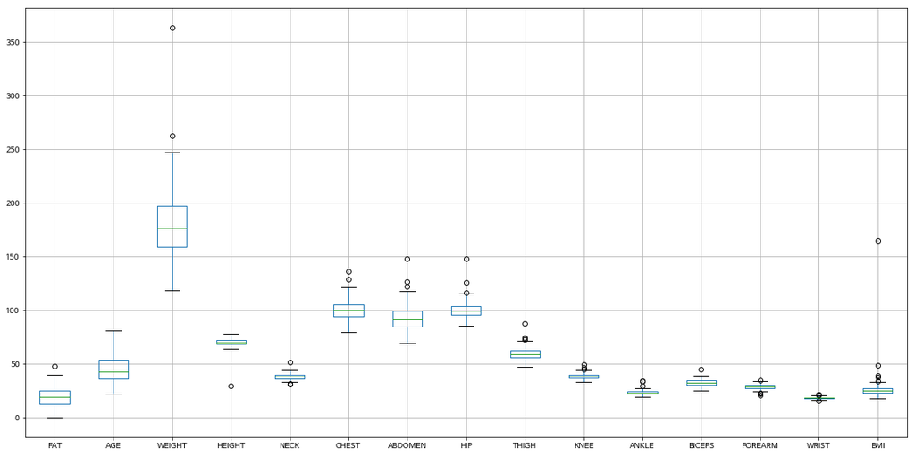

```python
body.boxplot(figsize=(20,10))
```

#### 나이를 제외하고 모든 변수에서 outlier가 존재하는 것으로 보여진다. 특히 파생변수(BMI)에서 수치 164를 넘는 데이터가 관측되었는데, (https://en.wikipedia.org/wiki/Body_mass_index)에서 참조해본 결과, bmi 지수 60이 넘기는 매우 힘들다고 판단되며, 60이상의 수치에대해선 outlier라고 생각 하고 제거할 계획이다.

```python
# bmi >= 60 제거
body_reduced = body.where(body["BMI"] < 60)
#body_reduced.info()
np.isnan(body_reduced).sum()
body_reduced = body_reduced.dropna()
```

#### 자료 수는 251개로 BMI outlier 1개가 제거 되었다. nan하나가 생성되었는데, 제거한다.

```
array([[<matplotlib.axes._subplots.AxesSubplot object at 0x7fe07bd48da0>,
      dtype=object)
```

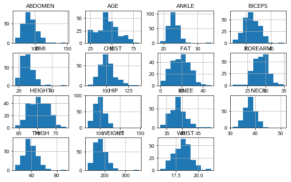

```python
body_reduced.hist(figsize=(10,6))
```

#### 목표변수인 FAT은 정규분포에 근접해 보이지만 조금 왼쪽에 쏠려 있는 형태로 보인다. 설명변수들은 대부분 왼쪽에 치우쳐져 있으며, Height 같은 경우 고르게 분포되있는것으로 보인다.

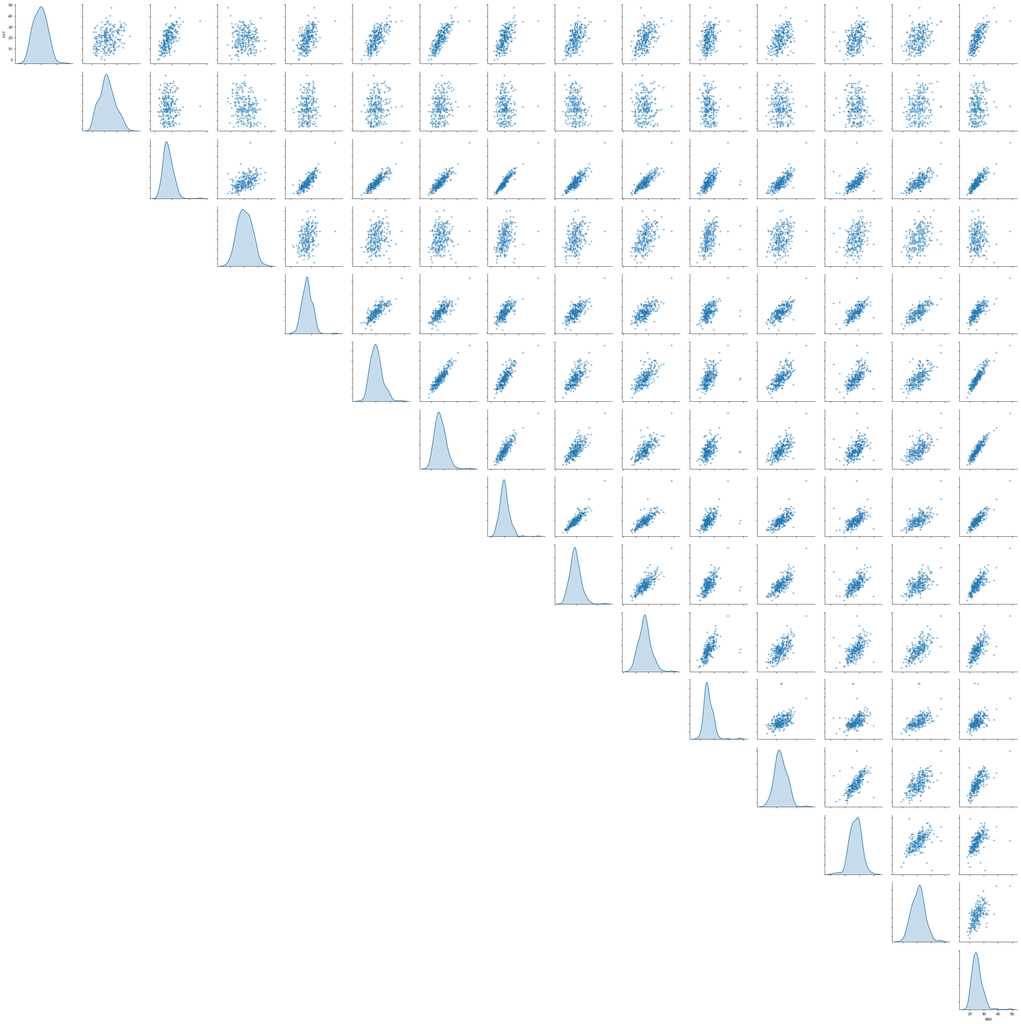

```python
g = sns.pairplot(body_reduced,diag_kind='kde',markers='+')
for i,j in zip(*np.triu_indices_from(g.axes,1)):
    g.axes[j,i].set_visible(False)
```

#### 목표변수 FAT은 산점도 그래프에서 ABDOMEN,HIP, BMI 와 양의 선형 상관관계가 있어 보인다. 실제로 복부와 엉덩이는 신체에서 지방을 가지고 있는 큰 부위이기도 하다.

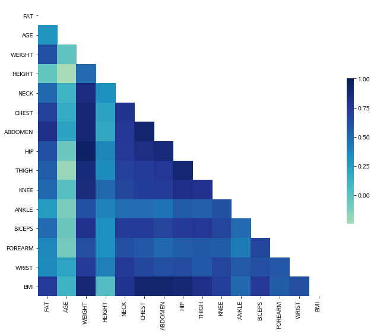

```python
colNm = list(body_reduced.head(0))
corr = body_reduced[colNm[0:]].corr(method='pearson')
f, ax = plt.subplots(figsize=(11,9))
cmap = sns.diverging_palette(220,10,as_cmap=True)
mask = np.zeros_like(corr,dtype = np.bool)
mask[np.triu_indices_from(mask)] = True
sns.heatmap(corr,mask=mask,cmap='YlGnBu',vmax=1,center=0.1,square=True,linewidths=0,
           cbar_kws={"shrink":.5})
```

#### 목표변수 FAT과 역시 ABDOMEN,HIP, BMI가 관계가 컸고, WEIGHT, CHEST도 선형 관계가 있어보인다. 당연하게도 ABDOMEN과 HIP은 강한 양의 상관관계를 가지고 있고, ABDOMEN과 CHEST도 마찬가지이다. 다중공선성을 의심해볼만 하다.

## Liner Regression Modeling

```python
b_y = body_reduced["FAT"]
b_x = body_reduced.drop(["FAT"],axis=1,inplace=False)
print("목표변수 데이터 크기:{}".format(b_y.shape))
print("설명변수 데이터 크기:{}".format(b_x.shape))
#절편 추가
b_x_const = sm.add_constant(b_x)
reg_multi_model = sm.OLS(b_y,b_x_const)
reg_multi_results = reg_multi_model.fit()
print(reg_multi_results.summary())
```

```
목표변수 데이터 크기:(251,)
설명변수 데이터 크기:(251, 14)
                            OLS Regression Results
==============================================================================
Dep. Variable:                    FAT   R-squared:                       0.754
Model:                            OLS   Adj. R-squared:                  0.739
Method:                 Least Squares   F-statistic:                     51.59
Date:                Mon, 11 Feb 2019   Prob (F-statistic):           1.29e-63
Time:                        20:22:01   Log-Likelihood:                -712.18
No. Observations:                 251   AIC:                             1454.
Df Residuals:                     236   BIC:                             1507.
Df Model:                          14
Covariance Type:            nonrobust
==============================================================================
                 coef    std err          t      P>|t|      [0.025      0.975]
------------------------------------------------------------------------------
const       -148.1387     52.793     -2.806      0.005    -252.143     -44.134
AGE            0.0700      0.032      2.178      0.030       0.007       0.133
WEIGHT        -0.4455      0.146     -3.055      0.003      -0.733      -0.158
HEIGHT         1.9197      0.760      2.527      0.012       0.423       3.416
NECK          -0.4481      0.234     -1.919      0.056      -0.908       0.012
CHEST         -0.0810      0.105     -0.774      0.440      -0.287       0.125
ABDOMEN        0.9060      0.092      9.900      0.000       0.726       1.086
HIP           -0.2916      0.149     -1.962      0.051      -0.584       0.001
THIGH          0.2448      0.145      1.689      0.093      -0.041       0.530
KNEE           0.0904      0.247      0.366      0.715      -0.397       0.577
ANKLE          0.1214      0.221      0.549      0.584      -0.314       0.557
BICEPS         0.1923      0.171      1.127      0.261      -0.144       0.528
FOREARM        0.3613      0.200      1.806      0.072      -0.033       0.755
WRIST         -1.7284      0.531     -3.255      0.001      -2.775      -0.682
BMI            2.9149      1.096      2.659      0.008       0.755       5.075
==============================================================================
Omnibus:                        4.133   Durbin-Watson:                   2.110
Prob(Omnibus):                  0.127   Jarque-Bera (JB):                2.783
Skew:                           0.062   Prob(JB):                        0.249
Kurtosis:                       2.499   Cond. No.                     5.50e+04
==============================================================================

Warnings:
[1] Standard Errors assume that the covariance matrix of the errors is correctly specified.
[2] The condition number is large, 5.5e+04. This might indicate that there are
strong multicollinearity or other numerical problems.
```

#### HIP이 모델에서 유의하지 않다고 나오는데 VIF도 같이 확인해 보겠다.

```python
full_vif = pd.DataFrame()
full_vif["variable"] = b_x_const.columns
full_vif["vif"] = [variance_inflation_factor(b_x_const.values,i)
                for i in range(b_x_const.shape[1])]
full_vif.sort_values("vif",inplace =True)
full_vif.round(3)
```

|  | variable | vif |
| --- | --- | --- |
| 10 | ANKLE | 1.941 |
| 12 | FOREARM | 2.259 |
| 1 | AGE | 2.270 |
| 13 | WRIST | 3.389 |
| 11 | BICEPS | 3.671 |
| 4 | NECK | 4.451 |
| 9 | KNEE | 4.863 |
| 8 | THIGH | 7.864 |
| 5 | CHEST | 10.759 |
| 6 | ABDOMEN | 13.406 |
| 7 | HIP | 15.385 |
| 3 | HEIGHT | 54.323 |
| 14 | BMI | 218.043 |
| 2 | WEIGHT | 253.241 |
| 0 | const | 38549.551 |

```python
#RFE(Recursive feature elimination)함수:입력된 모델을 이용하여 변수중요도가 낮은 순으로 순차적으로 제거
#sklearn의 선형회귀 모델
model = LinearRegression()
#전체의 변수 중 3개의 변수가 남을 때가지 변수 제거
rfe = RFE(estimator=model, n_features_to_select=3).fit(b_x,b_y)
#선택된 변수
selected_cols = b_x.columns[rfe.support_]
#제거된 변수
removed_cols = b_x.columns[~rfe.support_]

print("Selected Variables: {}".format(selected_cols))
print("Removed Variables: {}".format(removed_cols))
```

```
Selected Variables: Index(['ABDOMEN', 'WRIST', 'BMI'], dtype='object')
Removed Variables: Index(['AGE', 'WEIGHT', 'HEIGHT', 'NECK', 'CHEST', 'HIP', 'THIGH', 'KNEE',
       'ANKLE', 'BICEPS', 'FOREARM'],
      dtype='object')
```

```python
#후진제거법에 의하여 선택된 데이터
b_x_rfe = sm.add_constant(b_x_const[selected_cols])
#회귀 모델 생성
reg_multi_rfe_model = sm.OLS(b_y,b_x_rfe)
#적합
reg_multi_rfe_results = reg_multi_rfe_model.fit()
print(reg_multi_rfe_results.summary())
```

```
                            OLS Regression Results
==============================================================================
Dep. Variable:                    FAT   R-squared:                       0.700
Model:                            OLS   Adj. R-squared:                  0.696
Method:                 Least Squares   F-statistic:                     192.1
Date:                Mon, 11 Feb 2019   Prob (F-statistic):           2.88e-64
Time:                        20:22:09   Log-Likelihood:                -736.97
No. Observations:                 251   AIC:                             1482.
Df Residuals:                     247   BIC:                             1496.
Df Model:                           3
Covariance Type:            nonrobust
==============================================================================
                 coef    std err          t      P>|t|      [0.025      0.975]
------------------------------------------------------------------------------
const        -10.4794      6.105     -1.717      0.087     -22.503       1.544
ABDOMEN        0.7960      0.070     11.326      0.000       0.658       0.934
WRIST         -2.2046      0.407     -5.421      0.000      -3.006      -1.404
BMI           -0.1537      0.211     -0.729      0.466      -0.569       0.261
==============================================================================
Omnibus:                        0.736   Durbin-Watson:                   2.093
Prob(Omnibus):                  0.692   Jarque-Bera (JB):                0.520
Skew:                          -0.097   Prob(JB):                        0.771
Kurtosis:                       3.108   Cond. No.                     2.07e+03
==============================================================================

Warnings:
[1] Standard Errors assume that the covariance matrix of the errors is correctly specified.
[2] The condition number is large, 2.07e+03. This might indicate that there are
strong multicollinearity or other numerical problems.
```

#### BMI의 회귀계수가 유의수준을 초과하였다. 또한 VIF 값이 처음에 상당히 컸는데,이는 몸무게와 키의 파생변수로써, 지방과 밀접한 관련이 있을거라 추정되는 몸무게를 BMI대신 넣어 보겠다.

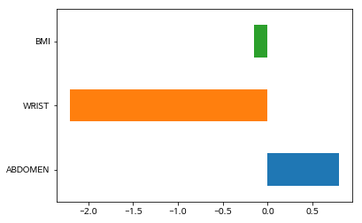

```python
#page40
ds_reg_coef = pd.DataFrame({"Coef":reg_multi_rfe_results.params.values[1:]},
                          index = reg_multi_rfe_model.exog_names[1:])
ds_reg_coef.plot.barh(y="Coef",legend=False)
```

#### 표준화 되있지 않아 wrist가 무척 크게 차지 하는것 처럼 보인다. 표준화 해보겠다.

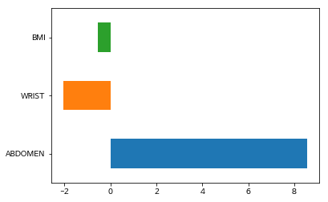

```python
#page41
#데이터 표준화, 평균0, 표준편차 1
b_x_scaled = scale(b_x_const[selected_cols])
#후진제거법에 의하여 선택된 데이터에 상수 1입력
b_x_scaled = sm.add_constant(b_x_scaled)

#회귀 모델 생성
reg_multi_scaled_model = sm.OLS(b_y,b_x_scaled)
#적합
reg_multi_scaled_results = reg_multi_scaled_model.fit()
#설명변수 중요도
ds_reg_scaled_coef = pd.DataFrame({"Coef":reg_multi_scaled_results.params.values[1:]},
                                 index = reg_multi_rfe_model.exog_names[1:])
ds_reg_scaled_coef.plot.barh(y="Coef",legend=False)
```

#### Abdomen이 가장 중요하게 보여지며, wrist, bmi순으로 중요하게 보여진다.

```python
# BMI 대신 WEIGHT변수 사용
b_y = body_reduced["FAT"]
b_x = body_reduced.drop(["FAT","BICEPS","FOREARM","THIGH","NECK",
                        "BMI","KNEE","ANKLE","HIP","CHEST","HEIGHT","AGE"]
                        ,axis=1,inplace=False)
print("목표변수 데이터 크기:{}".format(b_y.shape))
print("설명변수 데이터 크기:{}".format(b_x.shape))
#절편 추가
b_x_const = sm.add_constant(b_x)
reg_multi_model = sm.OLS(b_y,b_x_const)
reg_multi_results = reg_multi_model.fit()
print(reg_multi_results.summary())
```

```
목표변수 데이터 크기:(251,)
설명변수 데이터 크기:(251, 3)
                            OLS Regression Results
==============================================================================
Dep. Variable:                    FAT   R-squared:                       0.726
Model:                            OLS   Adj. R-squared:                  0.723
Method:                 Least Squares   F-statistic:                     218.0
Date:                Mon, 11 Feb 2019   Prob (F-statistic):           4.22e-69
Time:                        19:34:32   Log-Likelihood:                -725.64
No. Observations:                 251   AIC:                             1459.
Df Residuals:                     247   BIC:                             1473.
Df Model:                           3
Covariance Type:            nonrobust
==============================================================================
                 coef    std err          t      P>|t|      [0.025      0.975]
------------------------------------------------------------------------------
const        -28.6458      6.857     -4.178      0.000     -42.151     -15.141
WEIGHT        -0.1159      0.024     -4.891      0.000      -0.163      -0.069
ABDOMEN        0.9735      0.056     17.330      0.000       0.863       1.084
WRIST         -1.1847      0.441     -2.689      0.008      -2.052      -0.317
==============================================================================
Omnibus:                        3.264   Durbin-Watson:                   2.111
Prob(Omnibus):                  0.196   Jarque-Bera (JB):                2.383
Skew:                          -0.065   Prob(JB):                        0.304
Kurtosis:                       2.541   Cond. No.                     5.06e+03
==============================================================================

Warnings:
[1] Standard Errors assume that the covariance matrix of the errors is correctly specified.
[2] The condition number is large, 5.06e+03. This might indicate that there are
strong multicollinearity or other numerical problems.
```

#### 복부 대신 지방이 많은 엉덩이를 사용해 보겠다.

```python
# ABDOMEN 대신 HIP 사용, WEIGHT, WRIST,변수 사용
b_y = body_reduced["FAT"]
b_x = body_reduced.drop(["FAT","BICEPS","FOREARM","THIGH","NECK",
                        "BMI","KNEE","ANKLE","CHEST","HEIGHT","AGE","ABDOMEN"]
                        ,axis=1,inplace=False)
print("목표변수 데이터 크기:{}".format(b_y.shape))
print("설명변수 데이터 크기:{}".format(b_x.shape))
#절편 추가
b_x_const = sm.add_constant(b_x)
reg_multi_model = sm.OLS(b_y,b_x_const)
reg_multi_results = reg_multi_model.fit()
print(reg_multi_results.summary())
```

```
목표변수 데이터 크기:(251,)
설명변수 데이터 크기:(251, 3)
                            OLS Regression Results
==============================================================================
Dep. Variable:                    FAT   R-squared:                       0.403
Model:                            OLS   Adj. R-squared:                  0.396
Method:                 Least Squares   F-statistic:                     55.66
Date:                Mon, 11 Feb 2019   Prob (F-statistic):           1.61e-27
Time:                        19:34:55   Log-Likelihood:                -823.23
No. Observations:                 251   AIC:                             1654.
Df Residuals:                     247   BIC:                             1669.
Df Model:                           3
Covariance Type:            nonrobust
==============================================================================
                 coef    std err          t      P>|t|      [0.025      0.975]
------------------------------------------------------------------------------
const        -12.8085     15.718     -0.815      0.416     -43.766      18.149
WEIGHT         0.1225      0.049      2.518      0.012       0.027       0.218
HIP            0.3787      0.178      2.123      0.035       0.027       0.730
WRIST         -1.5252      0.663     -2.299      0.022      -2.832      -0.219
==============================================================================
Omnibus:                        0.227   Durbin-Watson:                   2.145
Prob(Omnibus):                  0.893   Jarque-Bera (JB):                0.192
Skew:                          -0.067   Prob(JB):                        0.909
Kurtosis:                       2.985   Cond. No.                     7.98e+03
==============================================================================

Warnings:
[1] Standard Errors assume that the covariance matrix of the errors is correctly specified.
[2] The condition number is large, 7.98e+03. This might indicate that there are
strong multicollinearity or other numerical problems.
```

#### ABDOMEN 대신 HIP사용시 모델 설명력이 크게 떨어 졌다. 복부 변수가 선형 관계에서는 좋은 설명력을 갖는것으로 추정된다. 다음모델에선 ABDOMEN대신 CHEST를 사용해 보겠다.

```python
# ABDOMEN 대신 CHEST 사용, WEIGHT, WRIST,변수 사용
b_y = body_reduced["FAT"]
b_x = body_reduced.drop(["FAT","BICEPS","FOREARM","THIGH","NECK",
                        "BMI","KNEE","ANKLE","HEIGHT","AGE","ABDOMEN","HIP"]
                        ,axis=1,inplace=False)
print("목표변수 데이터 크기:{}".format(b_y.shape))
print("설명변수 데이터 크기:{}".format(b_x.shape))
#절편 추가
b_x_const = sm.add_constant(b_x)
reg_multi_model = sm.OLS(b_y,b_x_const)
reg_multi_results = reg_multi_model.fit()
print(reg_multi_results.summary())
```

```
목표변수 데이터 크기:(251,)
설명변수 데이터 크기:(251, 3)
                            OLS Regression Results
==============================================================================
Dep. Variable:                    FAT   R-squared:                       0.517
Model:                            OLS   Adj. R-squared:                  0.511
Method:                 Least Squares   F-statistic:                     88.17
Date:                Mon, 11 Feb 2019   Prob (F-statistic):           8.16e-39
Time:                        19:35:00   Log-Likelihood:                -796.68
No. Observations:                 251   AIC:                             1601.
Df Residuals:                     247   BIC:                             1615.
Df Model:                           3
Covariance Type:            nonrobust
==============================================================================
                 coef    std err          t      P>|t|      [0.025      0.975]
------------------------------------------------------------------------------
const        -27.5139      9.952     -2.765      0.006     -47.116      -7.911
WEIGHT         0.0184      0.031      0.595      0.552      -0.042       0.079
CHEST          0.7791      0.098      7.985      0.000       0.587       0.971
WRIST         -1.9314      0.583     -3.315      0.001      -3.079      -0.784
==============================================================================
Omnibus:                        1.825   Durbin-Watson:                   2.212
Prob(Omnibus):                  0.402   Jarque-Bera (JB):                1.743
Skew:                           0.121   Prob(JB):                        0.418
Kurtosis:                       2.671   Cond. No.                     5.64e+03
==============================================================================

Warnings:
[1] Standard Errors assume that the covariance matrix of the errors is correctly specified.
[2] The condition number is large, 5.64e+03. This might indicate that there are
strong multicollinearity or other numerical problems.
```

#### 마찬가지로 설명력이 좋지 않다. ABDOMEN를 사용하겠다.

```python
#BMI을 빼보겠다.
# + ABDOMEN + HIP + CHEST
b_y = body_reduced["FAT"]
b_x = body_reduced.drop(["FAT","BICEPS","FOREARM","WRIST","THIGH","NECK",
                        "WEIGHT","AGE","KNEE","ANKLE","HEIGHT","BMI"]
                        ,axis=1,inplace=False)
print("목표변수 데이터 크기:{}".format(b_y.shape))
print("설명변수 데이터 크기:{}".format(b_x.shape))
#절편 추가
b_x_const = sm.add_constant(b_x)
reg_multi_model = sm.OLS(b_y,b_x_const)
reg_multi_results = reg_multi_model.fit()
print(reg_multi_results.summary())
```

```
목표변수 데이터 크기:(251,)
설명변수 데이터 크기:(251, 3)
                            OLS Regression Results
==============================================================================
Dep. Variable:                    FAT   R-squared:                       0.701
Model:                            OLS   Adj. R-squared:                  0.697
Method:                 Least Squares   F-statistic:                     193.1
Date:                Mon, 11 Feb 2019   Prob (F-statistic):           1.83e-64
Time:                        19:35:04   Log-Likelihood:                -736.51
No. Observations:                 251   AIC:                             1481.
Df Residuals:                     247   BIC:                             1495.
Df Model:                           3
Covariance Type:            nonrobust
==============================================================================
                 coef    std err          t      P>|t|      [0.025      0.975]
------------------------------------------------------------------------------
const        -12.9272      5.211     -2.481      0.014     -23.191      -2.663
CHEST         -0.1851      0.087     -2.132      0.034      -0.356      -0.014
ABDOMEN        1.0071      0.078     12.950      0.000       0.854       1.160
HIP           -0.4255      0.085     -4.983      0.000      -0.594      -0.257
==============================================================================
Omnibus:                        2.426   Durbin-Watson:                   2.166
Prob(Omnibus):                  0.297   Jarque-Bera (JB):                1.912
Skew:                           0.048   Prob(JB):                        0.384
Kurtosis:                       2.583   Cond. No.                     3.06e+03
==============================================================================

Warnings:
[1] Standard Errors assume that the covariance matrix of the errors is correctly specified.
[2] The condition number is large, 3.06e+03. This might indicate that there are
strong multicollinearity or other numerical problems.
```

#### BMI는 설명력이 높지 않아 빼기로 한다. BMI를설명하는 키와 몸무게를 추가하겠다.

```python
# WEIGHT 대신 HEIGHT사용, ABDOMEN, WRIST사용
b_y = body_reduced["FAT"]
b_x = body_reduced.drop(["FAT","BICEPS","FOREARM","THIGH","NECK",
                        "BMI","KNEE","ANKLE","HIP","CHEST","WEIGHT","AGE"]
                        ,axis=1,inplace=False)
print("목표변수 데이터 크기:{}".format(b_y.shape))
print("설명변수 데이터 크기:{}".format(b_x.shape))
#절편 추가
b_x_const = sm.add_constant(b_x)
reg_multi_model = sm.OLS(b_y,b_x_const)
reg_multi_results = reg_multi_model.fit()
print(reg_multi_results.summary())
```

```
목표변수 데이터 크기:(251,)
설명변수 데이터 크기:(251, 3)
                            OLS Regression Results
==============================================================================
Dep. Variable:                    FAT   R-squared:                       0.713
Model:                            OLS   Adj. R-squared:                  0.710
Method:                 Least Squares   F-statistic:                     205.0
Date:                Mon, 11 Feb 2019   Prob (F-statistic):           9.82e-67
Time:                        19:35:12   Log-Likelihood:                -731.19
No. Observations:                 251   AIC:                             1470.
Df Residuals:                     247   BIC:                             1484.
Df Model:                           3
Covariance Type:            nonrobust
==============================================================================
                 coef    std err          t      P>|t|      [0.025      0.975]
------------------------------------------------------------------------------
const         11.2007      8.165      1.372      0.171      -4.881      27.282
HEIGHT        -0.4150      0.119     -3.493      0.001      -0.649      -0.181
ABDOMEN        0.7419      0.034     21.880      0.000       0.675       0.809
WRIST         -1.7311      0.419     -4.136      0.000      -2.556      -0.907
==============================================================================
Omnibus:                        3.233   Durbin-Watson:                   2.055
Prob(Omnibus):                  0.199   Jarque-Bera (JB):                2.938
Skew:                          -0.197   Prob(JB):                        0.230
Kurtosis:                       3.354   Cond. No.                     3.40e+03
==============================================================================

Warnings:
[1] Standard Errors assume that the covariance matrix of the errors is correctly specified.
[2] The condition number is large, 3.4e+03. This might indicate that there are
strong multicollinearity or other numerical problems.
```

#### 설명력이 떨어 졌는데, 예상대서 몸무게가 지방에 더 큰 영향을 주는것으로 판단된다.

## Final Linear Model

```python
# WEIGHT, ABDOMEN, WRIST사용
b_y = body_reduced["FAT"]
b_x = body_reduced.drop(["FAT","BICEPS","FOREARM","THIGH","NECK",
                        "BMI","KNEE","ANKLE","HIP","CHEST","HEIGHT","AGE"]
                        ,axis=1,inplace=False)
print("목표변수 데이터 크기:{}".format(b_y.shape))
print("설명변수 데이터 크기:{}".format(b_x.shape))
#절편 추가
b_x_const = sm.add_constant(b_x)
reg_multi_model = sm.OLS(b_y,b_x_const)
reg_multi_results = reg_multi_model.fit()
print(reg_multi_results.summary())
```

```
목표변수 데이터 크기:(251,)
설명변수 데이터 크기:(251, 3)
                            OLS Regression Results
==============================================================================
Dep. Variable:                    FAT   R-squared:                       0.726
Model:                            OLS   Adj. R-squared:                  0.723
Method:                 Least Squares   F-statistic:                     218.0
Date:                Mon, 11 Feb 2019   Prob (F-statistic):           4.22e-69
Time:                        19:35:17   Log-Likelihood:                -725.64
No. Observations:                 251   AIC:                             1459.
Df Residuals:                     247   BIC:                             1473.
Df Model:                           3
Covariance Type:            nonrobust
==============================================================================
                 coef    std err          t      P>|t|      [0.025      0.975]
------------------------------------------------------------------------------
const        -28.6458      6.857     -4.178      0.000     -42.151     -15.141
WEIGHT        -0.1159      0.024     -4.891      0.000      -0.163      -0.069
ABDOMEN        0.9735      0.056     17.330      0.000       0.863       1.084
WRIST         -1.1847      0.441     -2.689      0.008      -2.052      -0.317
==============================================================================
Omnibus:                        3.264   Durbin-Watson:                   2.111
Prob(Omnibus):                  0.196   Jarque-Bera (JB):                2.383
Skew:                          -0.065   Prob(JB):                        0.304
Kurtosis:                       2.541   Cond. No.                     5.06e+03
==============================================================================

Warnings:
[1] Standard Errors assume that the covariance matrix of the errors is correctly specified.
[2] The condition number is large, 5.06e+03. This might indicate that there are
strong multicollinearity or other numerical problems.
```